# Práctica 3

Luis Antonio Domínguez Ávila

2023-10-2

Práctica 3

```r
tabla<-read.csv("rdchem.csv")
# tabla
```

1. A los economistas que se dedican al estudio de la organización industrial les interesa la relación entre el tamaño de la empresa —que suele medirse por las ventas anuales (sales)— y los gastos en investigación y desarrollo (rd). En el archivo redchem.csv, se considera una muestra de 32 empresas estadounidenses de la industria química (los detalles de estos datos se encuentran en el archivo wooldridge data.pdf) Considera el modelo

$\widehat{log(rd)}=\hat{\beta_{1}}+\hat{\beta_2}log(sales)$

1. Realiza el diagrama de dispersión.

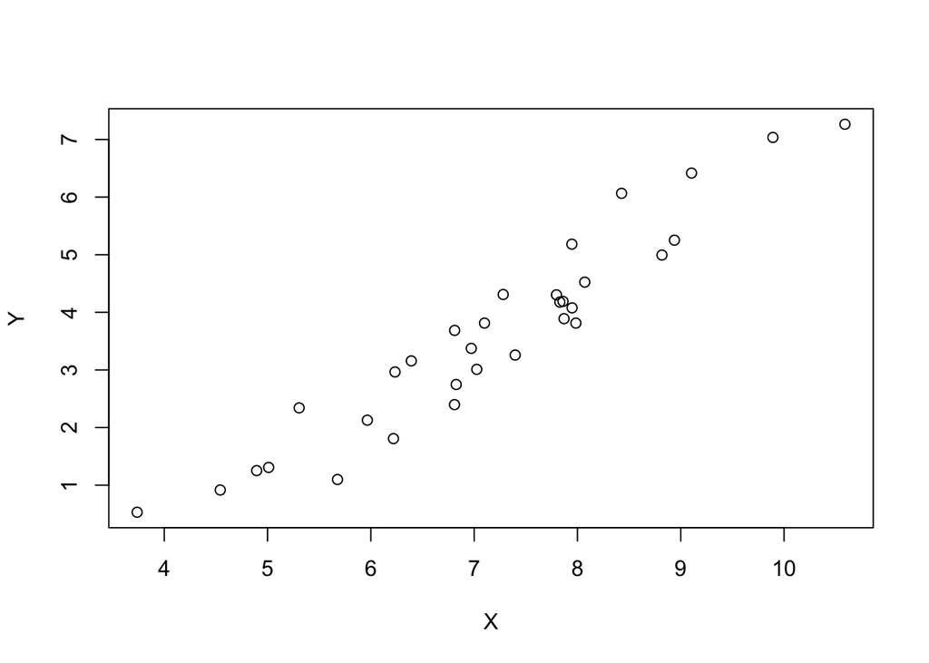

```r
tabla2 <- select(tabla,lsales,lrd)
tabla2<-rename(tabla2,X=lsales,Y=lrd)
plot(Y~X, data=tabla2)
```

2. Calcula el estimador $\hat{\beta_1}$

```r
modelo1<-lm(Y~X,data=tabla2)
summary(modelo1)
```

```
##
## Call:
## lm(formula = Y ~ X, data = tabla2)
##
## Residuals:
##      Min       1Q   Median       3Q      Max
## -0.90406 -0.40086 -0.02178  0.40562  1.10439
##
## Coefficients:
##             Estimate Std. Error t value Pr(>|t|)
## (Intercept) -4.10472    0.45277  -9.066 4.27e-10 ***
## X            1.07573    0.06183  17.399  < 2e-16 ***
## ---
## Signif. codes:  0 '***' 0.001 '**' 0.01 '*' 0.05 '.' 0.1 ' ' 1
##
## Residual standard error: 0.5294 on 30 degrees of freedom
## Multiple R-squared:  0.9098, Adjusted R-squared:  0.9068
## F-statistic: 302.7 on 1 and 30 DF,  p-value: < 2.2e-16
```

```r
b1<--4.10472
b1
```

```
## [1] -4.10472
```

3. Calcula el estimador $\hat{\beta_2}$

```r
b2<-1.07573
b2
```

```
## [1] 1.07573
```

4. Interpreta los estimadores.

Cuando las ventas anuales son de cero, los gastos en investigación y desarrollo son de -4.10472 millones de dólares. Y por cada 1% que aumentan las ventas anuales, los gastos en investigación y desarrollo aumentan en un 1.07573%

5. Calcula los intervalos de confianza para estos estimadores con $\alpha=0.05$

```r
confint(modelo1)
```

```
##                  2.5 %    97.5 %
## (Intercept) -5.0293976 -3.180047
## X            0.9494619  1.201999
```

El intervalo de confianza para $\hat{\beta_1}$ es de $(-5.0293976, -3.180047)$ y el intervalo de confianza para $\hat{\beta_2}$ es de $(0.9494619 1.201999)$

6. Determina si $\beta_2$ es significativo. Sí, ya que el intervalo no pasa por el cero.
7. Vuelve a realizar el diagrama de dispersión, ahora con la línea de regresión.

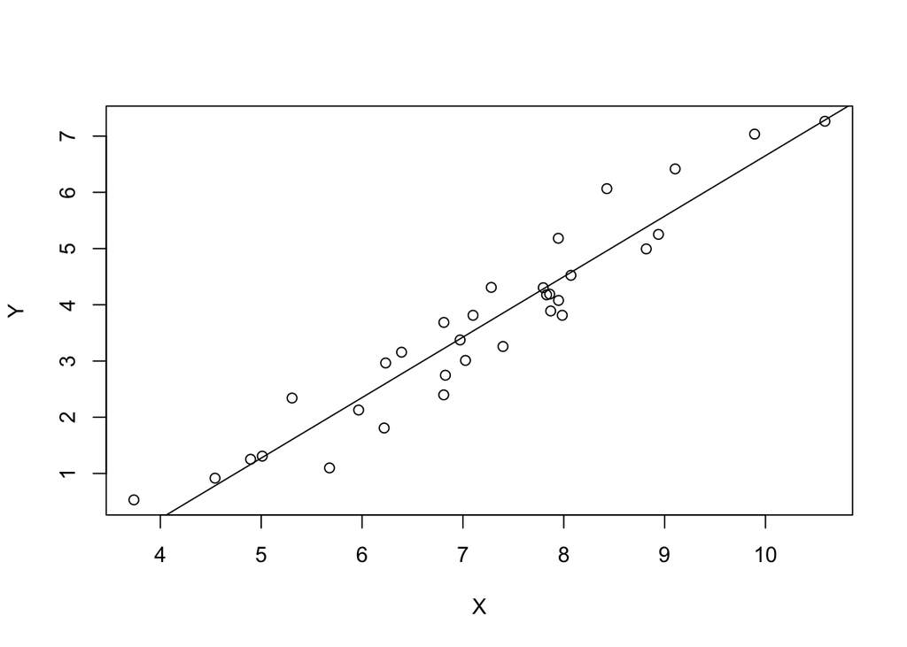

```r
plot(Y~X,data=tabla2)
# modelo1<-lm(Y~X,data=tabla2)
abline(modelo1)
```

8. Calcula $R^2$. Interpreta este valor.

```r
summary(modelo1)
```

```
##
## Call:
## lm(formula = Y ~ X, data = tabla2)
##
## Residuals:
##      Min       1Q   Median       3Q      Max
## -0.90406 -0.40086 -0.02178  0.40562  1.10439
##
## Coefficients:
##             Estimate Std. Error t value Pr(>|t|)
## (Intercept) -4.10472    0.45277  -9.066 4.27e-10 ***
## X            1.07573    0.06183  17.399  < 2e-16 ***
## ---
## Signif. codes:  0 '***' 0.001 '**' 0.01 '*' 0.05 '.' 0.1 ' ' 1
##
## Residual standard error: 0.5294 on 30 degrees of freedom
## Multiple R-squared:  0.9098, Adjusted R-squared:  0.9068
## F-statistic: 302.7 on 1 and 30 DF,  p-value: < 2.2e-16
```

```r
r2<-0.9098
r2
```

```
## [1] 0.9098
```

Aproximadamente el 90.98% de la variabilidad en los datos puede ser explicada por el modelo de regresión.

1. Calcula $var(\hat{\beta_1})$

```r
eeB1<-0.45277
varB1<-eeB1^2
varB1
```

```
## [1] 0.2050007
```

10. Calcula $var(\hat{\beta_2})$

```r
eeB2<-0.06183
varB2<-eeB2^2
varB2
```

```
## [1] 0.003822949
```

También puede ser interesante conocer el efecto del margen de utilidad —es decir, las utilidades como porcentaje de las ventas (profmarg)— sobre los gastos en Investigación y Desarrollo (rd). Repite el ejercicio anterior para el modelo

$\widehat{log(rd)}=\hat{\beta_{1}}+\hat{\beta_2}profmarg$

1. Realiza el diagrama de dispersión.

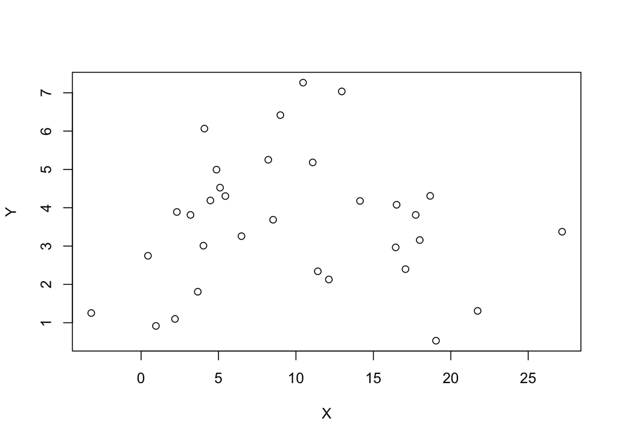

```r
tabla2 <- select(tabla,profmarg,lrd)
tabla2<-rename(tabla2,X=profmarg,Y=lrd)
plot(Y~X, data=tabla2)
```

2. Calcula el estimador $\hat{\beta_1}$

```r
modelo1<-lm(Y~X,data=tabla2)
summary(modelo1)
```

```
##
## Call:
## lm(formula = Y ~ X, data = tabla2)
##
## Residuals:
##     Min      1Q  Median      3Q     Max
## -3.0952 -1.2335  0.1388  0.7673  3.6596
##
## Coefficients:
##             Estimate Std. Error t value Pr(>|t|)
## (Intercept) 3.578372   0.530638   6.744 1.78e-07 ***
## X           0.002489   0.043722   0.057    0.955
## ---
## Signif. codes:  0 '***' 0.001 '**' 0.01 '*' 0.05 '.' 0.1 ' ' 1
##
## Residual standard error: 1.763 on 30 degrees of freedom
## Multiple R-squared:  0.000108,   Adjusted R-squared:  -0.03322
## F-statistic: 0.003242 on 1 and 30 DF,  p-value: 0.955
```

```r
b1<-3.578372
b1
```

```
## [1] 3.578372
```

3. Calcula el estimador $\hat{\beta_2}$

```r
b2<-0.002489
b2
```

```
## [1] 0.002489
```

4. Interpreta los estimadores.

Cuando el margen de utilidad de cero, los gastos en investigación y desarrollo son de 3.578372 millones de dólares. Y por cada 1% que aumenta el margen de utilidad, los gastos en investigación y desarrollo aumentan en 0.002489/100 unidades

5. Calcula los intervalos de confianza para estos estimadores con $\alpha=0.05$

```r
confint(modelo1)
```

```
##                   2.5 %     97.5 %
## (Intercept)  2.49466428 4.66208002
## X           -0.08680248 0.09178113
```

El intervalo de confianza para $\hat{\beta_1}$ es de $(2.49466428, 4.66208002)$ y el intervalo de confianza para $\hat{\beta_2}$ es de $(-0.08680248, 0.09178113)$

6. Determina si $\beta_2$ es significativo.

No, porque el intervalo pasa por el cero

7. Vuelve a realizar el diagrama de dispersión, ahora con la línea de regresión.

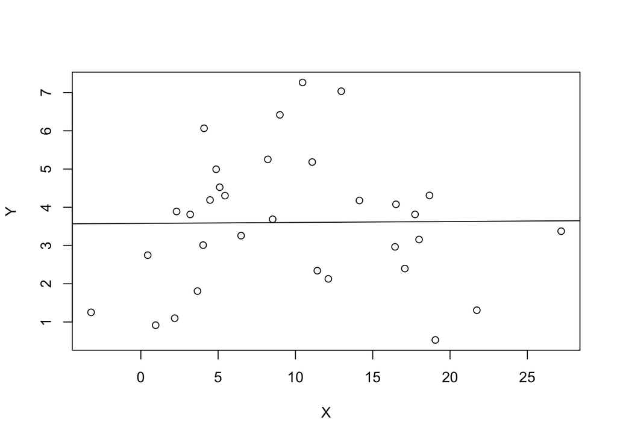

```r
plot(Y~X,data=tabla2)
# modelo1<-lm(Y~X,data=tabla2)
abline(modelo1)
```

8. Calcula $R^2$. Interpreta este valor.

```r
summary(modelo1)
```

```
##
## Call:
## lm(formula = Y ~ X, data = tabla2)
##
## Residuals:
##     Min      1Q  Median      3Q     Max
## -3.0952 -1.2335  0.1388  0.7673  3.6596
##
## Coefficients:
##             Estimate Std. Error t value Pr(>|t|)
## (Intercept) 3.578372   0.530638   6.744 1.78e-07 ***
## X           0.002489   0.043722   0.057    0.955
## ---
## Signif. codes:  0 '***' 0.001 '**' 0.01 '*' 0.05 '.' 0.1 ' ' 1
##
## Residual standard error: 1.763 on 30 degrees of freedom
## Multiple R-squared:  0.000108,   Adjusted R-squared:  -0.03322
## F-statistic: 0.003242 on 1 and 30 DF,  p-value: 0.955
```

```r
r2<-0.000108
r2
```

```
## [1] 0.000108
```

Aproximadamente el 0.01% de la variabilidad en los datos puede ser explicada por el modelo de regresión, lo cual nos habla de que es un ajuste muy débil

1. Calcula $var(\hat{\beta_1})$

```r
eeB1<-0.530638
varB1<-eeB1^2
varB1
```

```
## [1] 0.2815767
```

10. Calcula $var(\hat{\beta_2})$

```r
eeB2<-0.043722
varB2<-eeB2^2
varB2
```

```
## [1] 0.001911613
```